# 01_Polynomial_Regression

```python
import numpy as np
import pandas as pd
import matplotlib.pyplot as plt
import seaborn as sns
```

```python
df = pd.read_csv('Advertising.csv')
df.head()
```

|  | TV | radio | newspaper | sales |
| --- | --- | --- | --- | --- |
| 0 | 230.1 | 37.8 | 69.2 | 22.1 |
| 1 | 44.5 | 39.3 | 45.1 | 10.4 |
| 2 | 17.2 | 45.9 | 69.3 | 9.3 |
| 3 | 151.5 | 41.3 | 58.5 | 18.5 |
| 4 | 180.8 | 10.8 | 58.4 | 12.9 |

```python
X = df.drop('sales', axis = 1)
```

```python
y = df['sales']
```

```python
X.shape
```

```
(200, 3)
```

```python
y.shape
```

```
(200,)
```

### Polynomial Regression

#### For interaction terms

```python
from sklearn.preprocessing import PolynomialFeatures
```

```python
poly_converter = PolynomialFeatures(degree= 2, include_bias= False) # press shift + tab  # Use bias  to remove 1
```

```python
poly_converter.fit(X)
```

```
PolynomialFeatures(include_bias=False)
```

```python
poly_features = poly_converter.transform(X)    # 1 A B A^2 AB B^2 like this ( This one is degree 2)
poly_features
# ploy_converter.fit_transform(X) # In one line: Since we are doing fitting and transforming on same data set X.
```

```
array([[ 230.1 ,   37.8 ,   69.2 , ..., 1428.84, 2615.76, 4788.64],
       [  44.5 ,   39.3 ,   45.1 , ..., 1544.49, 1772.43, 2034.01],
       [  17.2 ,   45.9 ,   69.3 , ..., 2106.81, 3180.87, 4802.49],
       ...,
       [ 177.  ,    9.3 ,    6.4 , ...,   86.49,   59.52,   40.96],
       [ 283.6 ,   42.  ,   66.2 , ..., 1764.  , 2780.4 , 4382.44],
       [ 232.1 ,    8.6 ,    8.7 , ...,   73.96,   74.82,   75.69]])
```

```python
poly_features.shape
```

```
(200, 9)
```

```python
poly_features[0]
```

```
array([2.301000e+02, 3.780000e+01, 6.920000e+01, 5.294601e+04,
       8.697780e+03, 1.592292e+04, 1.428840e+03, 2.615760e+03,
       4.788640e+03])
```

```python
 # Lets check the above quantites what those are
X.iloc[0]  # Take thefirst row of feature and label.
```

```
TV           230.1
radio         37.8
newspaper     69.2
Name: 0, dtype: float64
```

```python
230.1**2
```

```
52946.009999999995
```

```python
37.8**2
```

```
1428.8399999999997
```

```python
69.2**2
```

```
4788.64
```

```python
# Interaction terms
230.1*37.8
```

```
8697.779999999999
```

```python
230.1*69.2
```

```
15922.92
```

```python
37.8*69.2
```

```
2615.7599999999998
```

##### We have converted the three feature space to 9 feature space:

### Train test split

```python
from sklearn.model_selection import train_test_split
```

```python
poly_features.shape
```

```
(200, 9)
```

```python
X_train, X_test, y_train, y_test = train_test_split(poly_features, y, test_size = 0.3, random_state= 101) # y - label
```

### Model

```python
from sklearn.linear_model import LinearRegression
```

```python
model = LinearRegression()
```

```python
model.fit(X_train, y_train)
```

```
LinearRegression()
```

```python
y_pred = model.predict(X_test)
```

```python
y_pred
```

```
array([13.94856153, 19.33480262, 12.31928162, 16.76286337,  7.90210901,
        6.94143792, 20.13372693, 17.50092709, 10.56889   , 20.12551788,
        9.44614537, 14.09935417, 12.05513493, 23.39254049, 19.67508393,
        9.15626258, 12.1163732 ,  9.28149557,  8.44604007, 21.65588129,
        7.05070331, 19.35854208, 27.26716369, 24.58689346,  9.03179421,
       11.81070232, 20.42630125,  9.19390639, 12.74795186,  8.64340674,
        8.66294151, 20.20047377, 10.93673817,  6.84639129, 18.27939359,
        9.47659449, 10.34242145,  9.6657038 ,  7.43347915, 11.03561332,
       12.65731013, 10.65459946, 11.20971496,  7.46199023, 11.38224982,
       10.27331262,  6.15573251, 15.50893362, 13.36092889, 22.71839277,
       10.40389682, 13.21622701, 14.23622207, 11.8723677 , 11.68463616,
        5.62217738, 25.03778913,  9.53507734, 17.37926571, 15.7534364 ])
```

```python
y_pred.shape
```

```
(60,)
```

### Evaluation

```python
from sklearn.metrics import mean_absolute_error, mean_squared_error
```

```python
MAE = mean_absolute_error(y_test, y_pred)
```

```python
MAE
```

```
0.4896798044803721
```

```python
MSE = mean_squared_error(y_test, y_pred)
```

```python
MSE
```

```
0.4417505510403673
```

```python
RMSE = np.sqrt(MSE)
RMSE
```

```
0.6646431757269214
```

### Check the beta coeff

```python
model.coef_ # coeff of all my features : beta for all 9 terms including the interaction terms.
```

```
array([ 5.17095811e-02,  1.30848864e-02,  1.20000085e-02, -1.10892474e-04,
        1.14212673e-03, -5.24100082e-05,  3.34919737e-05,  1.46380310e-04,
       -3.04715806e-05])
```

#### Note we can vary the degree as well, up to what degree we can go?

- **Bias - Variance Trade off**.
- Extereme var leads to overfit.: It will results low error in training sets, but more error in prediction/Test set)
- Extreme bias lead to Underfit.

## Bias–Variance Trade-off

- **Bias**: Error due to overly simplistic assumptions in the model.
  - **High bias** → **Underfitting**
  - The model misses relevant relations between input and output.
  - Example: Linear model used to fit nonlinear data.
- **Variance**: Error due to too much complexity in the model.
  - **High variance** → **Overfitting**
  - The model captures noise as if it were a pattern.
  - Example: Deep decision trees memorizing training data.
- **Trade-off**:
  - A model with **too much bias** performs poorly on training **and** test data.
  - A model with **too much variance** performs well on training data, but poorly on unseen data.
  - The goal is to find a **sweet spot** where both bias and variance are minimized enough to **generalize well**.

### Summary

| Model Behavior | Bias | Variance | Training Error | Test Error |
| --- | --- | --- | --- | --- |
| Underfitting | High | Low | High | High |
| Overfitting | Low | High | Low | High |
| Good Generalization | Balanced | Balanced | Low | Low (ideally) |

## 🔁 Bias–Variance Trade-off

- **Bias**: Error due to overly simplistic assumptions in the model.
  - **High bias** → **Underfitting**
  - The model misses relevant relations between input and output.
  - 🧠 *Example*: Trying to fit a straight line to curved data (e.g., using Linear Regression for a quadratic relationship).
- **Variance**: Error due to too much complexity in the model.
  - **High variance** → **Overfitting**
  - The model captures noise as if it were a pattern.
  - 🧠 *Example*: Using a deep decision tree on a small dataset, leading to perfect training accuracy but poor generalization.
- **Trade-off**:
  - A model with **too much bias** performs poorly on training **and** test data.
  - A model with **too much variance** performs well on training data, but poorly on unseen data.
  - ✅ Goal: Find a **sweet spot** where both bias and variance are balanced for good generalization.

### ✅ Summary

| Model Behavior | Bias | Variance | Training Error | Test Error | Example |
| --- | --- | --- | --- | --- | --- |
| Underfitting | High | Low | High | High | Linear Regression on nonlinear data |
| Overfitting | Low | High | Low | High | Deep tree on small/noisy dataset |
| Good Generalization | Balanced | Balanced | Low | Low (ideal) | Regularized model / tuned model |

## 🎯 Is Bias–Variance Trade-off a Spectrum?

Yes — the **bias–variance trade-off** is best understood as a **spectrum**, not a binary concept.

### 🔵⚖️🔴 Bias–Variance as a Sliding Scale

- **High Bias / Low Variance** → **Underfitting**
  - Model is too simple to capture the true pattern in the data.
  - Example: Fitting a straight line to curved data.
- **Low Bias / High Variance** → **Overfitting**
  - Model is too complex and learns noise as if it were a pattern.
  - Example: Deep neural network trained on small noisy data.
- ✅ **Goal**: Find a **sweet spot** where **bias and variance are balanced**, leading to good generalization on unseen data.

### 📉 Bias–Variance Curve (Conceptual)

A common plot shows:

- **Model complexity** on the x-axis
- **Prediction error** on the y-axis

As model complexity increases:

- **Bias decreases**
- **Variance increases**
- **Total error first drops (better)**, then rises (worse)

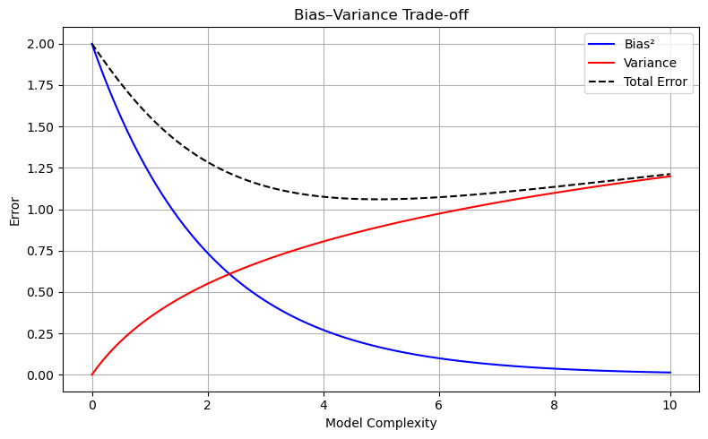

```python
import numpy as np
import matplotlib.pyplot as plt

# Model complexity range
complexity = np.linspace(0, 10, 100)

# Simulated curves
bias = np.exp(-0.5 * complexity) * 2
variance = np.log1p(complexity) * 0.5
total_error = bias + variance

# Plot
plt.figure(figsize=(8, 5))
plt.plot(complexity, bias, label="Bias²", color='blue')
plt.plot(complexity, variance, label="Variance", color='red')
plt.plot(complexity, total_error, label="Total Error", color='black', linestyle='--')

# Labels and legend
plt.title("Bias–Variance Trade-off") #In bias * 2 is just a scaling factor
plt.xlabel("Model Complexity")
plt.ylabel("Error")
plt.legend()
plt.grid(True)
plt.tight_layout()
plt.show()
```

- In case of polynomial regression: This model complexity is th *** order of the polynomial***

```python
import numpy as np

x = 1e-10

print(np.log1p(x))       # More accurate  log(1+x) to avoid the num error when x is very small
np.log(1 + x)     # Might lose precision
```

```
9.999999999500001e-11
```

```
1.000000082690371e-10
```

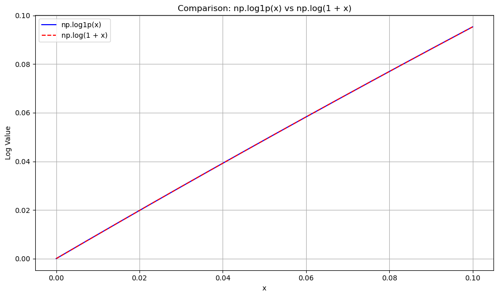

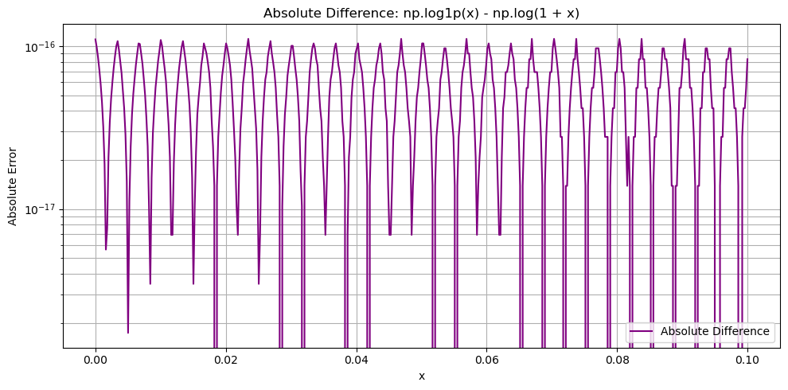

```python
import numpy as np
import matplotlib.pyplot as plt

# Define a range of small x values close to zero
x = np.linspace(1e-15, 1e-1, 500)

# Compute both versions
log1p_vals = np.log1p(x)
log_naive_vals = np.log(1 + x)
abs_diff = np.abs(log1p_vals - log_naive_vals)

# -------------------------------
# Plot 1: log1p(x) vs log(1 + x)
# -------------------------------
plt.figure(figsize=(10, 6))
plt.plot(x, log1p_vals, label="np.log1p(x)", color='blue')
plt.plot(x, log_naive_vals, label="np.log(1 + x)", color='red', linestyle='--')
plt.title("Comparison: np.log1p(x) vs np.log(1 + x)")
plt.xlabel("x")
plt.ylabel("Log Value")
plt.legend()
plt.grid(True)
plt.tight_layout()
plt.show()

# -----------------------------------------
# Plot 2: Absolute Difference between both
# -----------------------------------------
plt.figure(figsize=(10, 5))
plt.plot(x, abs_diff, label="Absolute Difference", color='purple')
plt.title("Absolute Difference: np.log1p(x) - np.log(1 + x)")
plt.xlabel("x")
plt.ylabel("Absolute Error")
plt.yscale('log')  # Use log scale to visualize small errors
plt.grid(True, which='both')
plt.legend()
plt.tight_layout()
plt.show()
```

### Choosing a Model (Bias -Var Trade off)

##### Adjusting the parameter

```python
from sklearn.preprocessing import PolynomialFeatures
from sklearn.model_selection import train_test_split
from sklearn.linear_model import LinearRegression
from sklearn.metrics import mean_squared_error
import numpy as np

# Lists to store errors
training_rmse_error = []
test_rmse_error = []

for d in range(1, 10):
    # Create a polynomial converter for each degree
    polynomial_converter = PolynomialFeatures(degree=d, include_bias=False)
    polynomial_features = polynomial_converter.fit_transform(X)

    # Split into train and test set
    X_train, X_test, y_train, y_test = train_test_split(
        polynomial_features, y, test_size=0.3, random_state=101
    )

    # Train the model
    poly_model = LinearRegression()
    poly_model.fit(X_train, y_train)

    # Predictions on training and testing data
    train_predictions = poly_model.predict(X_train)
    test_predictions = poly_model.predict(X_test)

    # Calculate RMSE
    train_RMSE = np.sqrt(mean_squared_error(y_train, train_predictions))
    test_RMSE = np.sqrt(mean_squared_error(y_test, test_predictions))

    # Append the errors
    training_rmse_error.append(train_RMSE)
    test_rmse_error.append(test_RMSE)
```

#### Plot the error

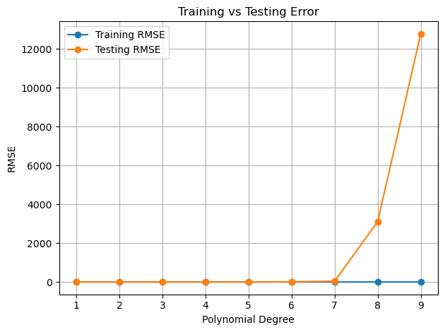

```python
import matplotlib.pyplot as plt

plt.plot(range(1, 10), training_rmse_error, label="Training RMSE", marker='o')
plt.plot(range(1, 10), test_rmse_error, label="Testing RMSE", marker='o')
plt.xlabel("Polynomial Degree")
plt.ylabel("RMSE")
plt.title("Training vs Testing Error")
plt.legend()
plt.grid(True)
plt.tight_layout()
plt.show()
```

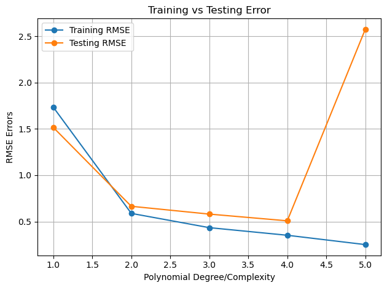

```python
import matplotlib.pyplot as plt

plt.plot(range(1, 6), training_rmse_error[:5], label="Training RMSE", marker='o')
plt.plot(range(1, 6), test_rmse_error[:5], label="Testing RMSE", marker='o')
plt.xlabel("Polynomial Degree/Complexity")
plt.ylabel("RMSE Errors")
plt.title("Training vs Testing Error")
plt.legend()
plt.grid(True)
plt.tight_layout()
plt.show()
```

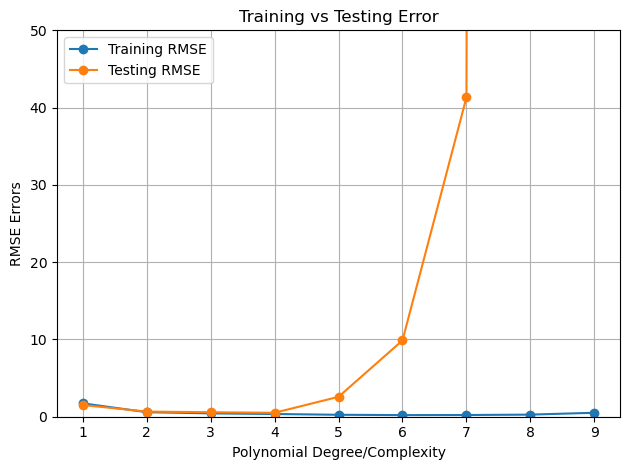

```python
import matplotlib.pyplot as plt

plt.plot(range(1, 10), training_rmse_error[:], label="Training RMSE", marker='o')
plt.plot(range(1, 10), test_rmse_error[:], label="Testing RMSE", marker='o')
plt.xlabel("Polynomial Degree/Complexity")
plt.ylim(0, 50)

plt.ylabel("RMSE Errors")
plt.title("Training vs Testing Error")
plt.legend()
plt.grid(True)
plt.tight_layout()
plt.show()
```

- Note: above is for particular random state and particular percentage of train test split.
- How o we know what random state, percentage of train test split is good?
- There are techniques: *****Cross validation error**** etc.

## 🧠 Model Evaluation: Why Not Just One Train-Test Split?

- Using a **fixed random state** and **fixed test size** gives only **one snapshot** of model performance.
- This can lead to **biased or high-variance estimates** of error.
- So how do we know what random state or test percentage is “good”?

## ✅ Better Approach: Cross-Validation

Cross-validation helps evaluate a model's generalization performance by splitting the data **multiple times in a structured way**.

### ⭐ Techniques

#### 1. **K-Fold Cross-Validation**

- The dataset is split into `k` equal-sized folds.
- Each fold is used once as a **test set**, the remaining `k-1` folds are used as **training set**.
- This process is repeated `k` times.
- The average of the test errors gives a **robust estimate** of model performance.

```
from sklearn.model_selection import cross_val_score
from sklearn.linear_model import LinearRegression
import numpy as np

model = LinearRegression()
scores = cross_val_score(model, X, y, cv=5, scoring='neg_root_mean_squared_error')
print("Average RMSE:", -np.mean(scores))
```

### 🔧 What is a Hyperparameter?

A **hyperparameter** is a configuration that is **set before** the learning process begins and **not learned** from the data. These values **control the training process** and influence the performance of a machine learning model.

### 📌 Examples of Hyperparameters:

| Model Type | Hyperparameters (Examples) |
| --- | --- |
| Linear Regression | Regularization strength (`alpha` in Ridge/Lasso) |
| Decision Trees | `max_depth`, `min_samples_split` |
| K-Nearest Neighbors | `n_neighbors`, distance metric |
| Neural Networks | Learning rate, number of layers, batch size |
| General (any model) | Number of training epochs, optimizer type |

### 🧠 Hyperparameters vs Parameters:

| Aspect | Hyperparameters | Parameters |
| --- | --- | --- |
| When Set | Before training | Learned during training |
| Examples | Learning rate, tree depth | Weights in linear regression or neural nets |
| Determined by | Developer/optimizer (via tuning) | Training algorithm (via data) |

### ⚙️ How to Choose Hyperparameters?

- Manually (trial and error)
- Grid Search
- Random Search
- **Cross-validation**: Evaluate combinations robustly
- **Bayesian Optimization**, **Genetic Algorithms**, etc.

### Finalizing the model using degree 3

```python
final_polynomial_conv = PolynomialFeatures(degree= 3, include_bias= False)  # bias false --> removes that 1
final_polynomial_conv.fit_transform(X)[0]  # now since order three this many 19 features, so we have to convert our input feature to this many features.
```

```
array([2.30100000e+02, 3.78000000e+01, 6.92000000e+01, 5.29460100e+04,
       8.69778000e+03, 1.59229200e+04, 1.42884000e+03, 2.61576000e+03,
       4.78864000e+03, 1.21828769e+07, 2.00135918e+06, 3.66386389e+06,
       3.28776084e+05, 6.01886376e+05, 1.10186606e+06, 5.40101520e+04,
       9.88757280e+04, 1.81010592e+05, 3.31373888e+05])
```

```python
final_model = LinearRegression()
final_model.fit(final_polynomial_conv.fit_transform(X),y)
```

```
LinearRegression()
```

```python
tv_spend = 123
radio_spend = 100
newspaper_spend = 50

final_polynomial_conv.transform([[tv_spend, radio_spend, newspaper_spend]]) # We have transformed our original ...
# ... features in to number of features that is required for the 3rd-order polynomial
```

```
array([[1.230000e+02, 1.000000e+02, 5.000000e+01, 1.512900e+04,
        1.230000e+04, 6.150000e+03, 1.000000e+04, 5.000000e+03,
        2.500000e+03, 1.860867e+06, 1.512900e+06, 7.564500e+05,
        1.230000e+06, 6.150000e+05, 3.075000e+05, 1.000000e+06,
        5.000000e+05, 2.500000e+05, 1.250000e+05]])
```

```python
poly_campaign = final_polynomial_conv.transform([[tv_spend, radio_spend, newspaper_spend]])
final_model.predict(poly_campaign)
```

```
array([29.27909063])
```

### Deployment and prediction

```python
from joblib import dump, load
dump(final_model, 'poly_model.joblib')
```

```
['poly_model.joblib']
```

```python
dump(final_polynomial_conv,'poly_converter.joblib')
```

```
['poly_converter.joblib']
```

### In new notebook: Predicting the new data:

```python
loaded_converter = load('poly_converter.joblib')
```

```python
loaded_model = load('poly_converter.joblib')
```

```python
campaign = [[123,45, 322], [123, 98, 45], [145, 78, 54]]
```

```python
campaign_poly = loaded_converter.transform(campaign)
```

```python
final_model.predict(campaign_poly)
```

```
array([-28.85280242,  28.66077421,  26.4276309 ])
```

### Regularization: